# ex 9 of ch 2

Which of the predictors are quantitative, and which are qualitative?

```r
library(ISLR)
data(Auto)
summary(Auto)
```

```
##       mpg          cylinders      displacement     horsepower        weight
##  Min.   : 9.00   Min.   :3.000   Min.   : 68.0   Min.   : 46.0   Min.   :1613
##  1st Qu.:17.00   1st Qu.:4.000   1st Qu.:105.0   1st Qu.: 75.0   1st Qu.:2225
##  Median :22.75   Median :4.000   Median :151.0   Median : 93.5   Median :2804
##  Mean   :23.45   Mean   :5.472   Mean   :194.4   Mean   :104.5   Mean   :2978
##  3rd Qu.:29.00   3rd Qu.:8.000   3rd Qu.:275.8   3rd Qu.:126.0   3rd Qu.:3615
##  Max.   :46.60   Max.   :8.000   Max.   :455.0   Max.   :230.0   Max.   :5140
##
##   acceleration        year           origin                      name
##  Min.   : 8.00   Min.   :70.00   Min.   :1.000   amc matador       :  5
##  1st Qu.:13.78   1st Qu.:73.00   1st Qu.:1.000   ford pinto        :  5
##  Median :15.50   Median :76.00   Median :1.000   toyota corolla    :  5
##  Mean   :15.54   Mean   :75.98   Mean   :1.577   amc gremlin       :  4
##  3rd Qu.:17.02   3rd Qu.:79.00   3rd Qu.:2.000   amc hornet        :  4
##  Max.   :24.80   Max.   :82.00   Max.   :3.000   chevrolet chevette:  4
##                                                  (Other)           :365
```

Which of the predictors are quantitative, and which are qualitative?

```r
lapply(Auto, class)
```

```
## $mpg
## [1] "numeric"
##
## $cylinders
## [1] "numeric"
##
## $displacement
## [1] "numeric"
##
## $horsepower
## [1] "numeric"
##
## $weight
## [1] "numeric"
##
## $acceleration
## [1] "numeric"
##
## $year
## [1] "numeric"
##
## $origin
## [1] "numeric"
##
## $name
## [1] "factor"
```

The column name is the only not numeric, therefore it is a qualitative. Also reading the data set information ?Auto, it is seen that the origin column is qualitative, factors described as numbers. The other columns are all quantitatives.

```r
origin <- as.factor(Auto$origin)
```

What is the range of each quantitative predictor? You can answer this using the range() function.

```r
cols.qlt = names(Auto) %in% c("name", "origin")
lapply(Auto[, !cols.qlt], range)
```

```
## $mpg
## [1]  9.0 46.6
##
## $cylinders
## [1] 3 8
##
## $displacement
## [1]  68 455
##
## $horsepower
## [1]  46 230
##
## $weight
## [1] 1613 5140
##
## $acceleration
## [1]  8.0 24.8
##
## $year
## [1] 70 82
```

What is the mean and standard deviation of each quantitative predictor?

```r
lapply(Auto[, !cols.qlt], function(x){ c('mean'=mean(x), 'sd'=sd(x))})
```

```
## $mpg
##      mean        sd
## 23.445918  7.805007
##
## $cylinders
##     mean       sd
## 5.471939 1.705783
##
## $displacement
##    mean      sd
## 194.412 104.644
##
## $horsepower
##      mean        sd
## 104.46939  38.49116
##
## $weight
##      mean        sd
## 2977.5842  849.4026
##
## $acceleration
##      mean        sd
## 15.541327  2.758864
##
## $year
##      mean        sd
## 75.979592  3.683737
```

4. Now remove the 10th through 85th observations. What is the range, mean, and standard deviation of each predictor in the subset of the data that remains?

```r
lapply(Auto[-(10:85), !cols.qlt], function(x){ c('mean'=mean(x), 'sd'=sd(x))})
```

```
## $mpg
##      mean        sd
## 24.404430  7.867283
##
## $cylinders
##     mean       sd
## 5.373418 1.654179
##
## $displacement
##      mean        sd
## 187.24051  99.67837
##
## $horsepower
##      mean        sd
## 100.72152  35.70885
##
## $weight
##      mean        sd
## 2935.9715  811.3002
##
## $acceleration
##      mean        sd
## 15.726899  2.693721
##
## $year
##      mean        sd
## 77.145570  3.106217
```

5. Using the full data set, investigate the predictors graphically, using scatterplots or other tools of your choice. Create some plots highlighting the relationships among the predictors. Comment on your findings.

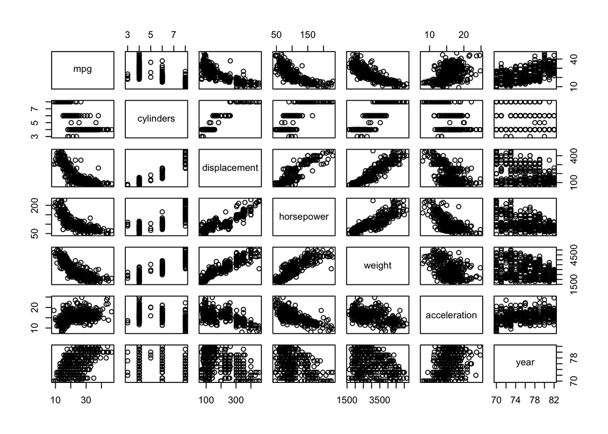

```r
pairs(Auto[, !cols.qlt])
```

Perceiving the graph, it is noticed many tends, some instances are mpg x cylinders, horsepower x weight, mpg x weight and displacement x acceleration. Visualize it closer.

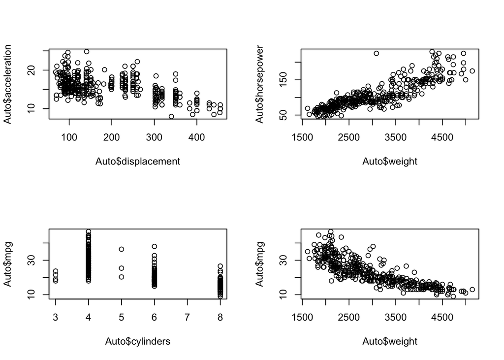

```r
par(mfrow=c(2,2))

plot(Auto$displacement,Auto$acceleration)
plot(Auto$weight, Auto$horsepower)
plot(Auto$cylinders, Auto$mpg)
plot(Auto$weight, Auto$mpg)
```

There is a linear tendency in all four graphs: mpg tends to decrease as cylinders or weight increases, whereas horsepower increases as weight increases, and acceleration and displacement have a negative correlation.

6. Suppose that we wish to predict gas mileage (mpg) on the basis of the other variables. Do your plots suggest that any of the other variables might be useful in predicting mpg? Justify your answer.

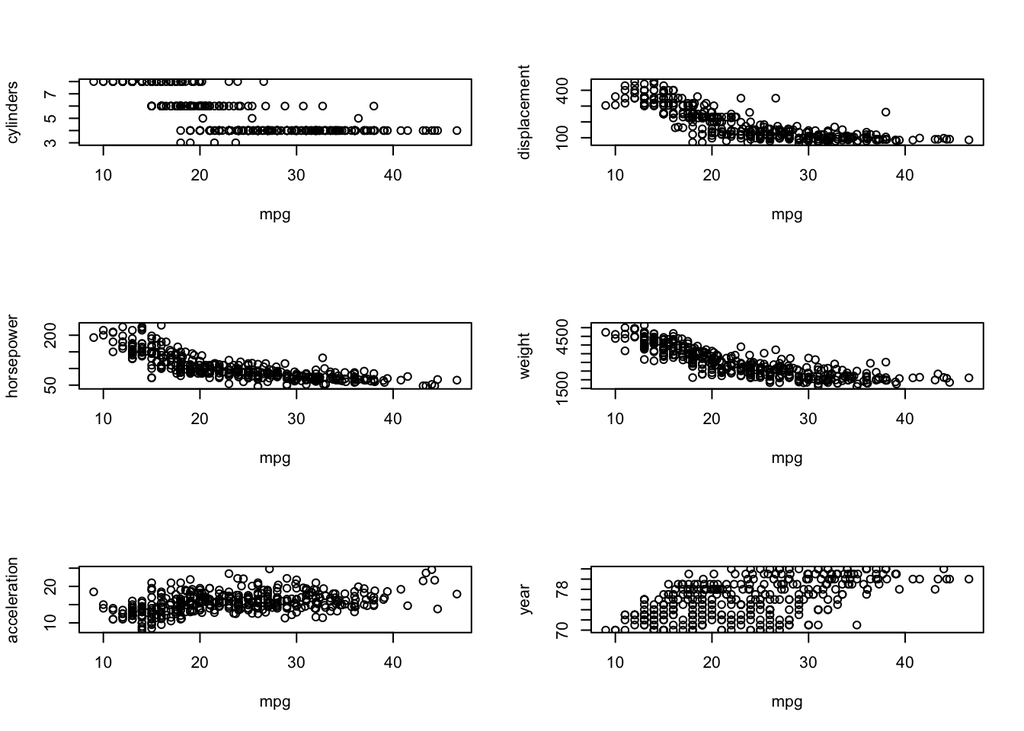

```r
par(mfrow=c(3,2))
for (i in 2:7){
  plot(Auto$mpg, Auto[,i], xlab="mpg" , ylab = names(Auto)[i])}
```